# **secr** closure simulations

Murray Efford

2024-06-14

# Closure CLO

The simulations described here are part of a series documenting the effect of breaching assumptions of spatially explicit capture–recapture models.

## Problem description

Effect of non-closure due to *in situ* births and deaths on density estimated by SECR for studies of different duration. Activity centres fixed.

## Settings

Square grid of 64 binary proximity detectors at 3000-m spacing.

The same conditions were used for simulation and fitting. Weekly ‘sessions’ were joined in `run.scenarios` for the final single-session analysis.

[output not shown]

## Package version, date and platform

```r
source('../setup.R')
runsim  <- FALSE
figures <- TRUE
cache   <- TRUE
nrepl   <- 1000
metadata(runsim) # if FALSE picks up saved metadata.RDS
```

```
## R version 4.3.2 (2023-10-31)
## Platform   x86_64-pc-linux-gnu (64-bit)
## Running    CentOS Linux 7 (Core)
## secr       4.6.7 2024-05-18
## secrdesign 2.9.1 2024-05-18
## Threads    40
## nrepl      1000
## Run        Thu Jun 13 09:31:22 2024
```

## Simulation code

```r
nsess  <- seq(4,24,4)
phi    <- c(0.5,0.75, 1.0)
phiw   <- exp(log(phi)/52)   # convert annual to weekly survival
grid   <- make.grid(nx = 8, ny = 8, spacing = 3000, detector = "proximity")
poparg <- expand.arg(
    buffer     = 10000,
    D          = 0.001,
    nsessions  = nsess,
    lambda     = 1,
    phi        = phiw,
    sublist = list(details=c('lambda','phi')))

# use lambda0 = 0.2 as approx weekly equiv daily 0.03
detarg <- list(traps = grid, detectfn = 'HHN', detectpar = list(lambda0 = 0.2, sigma = 2000),
               renumber = FALSE, noccasions = 1)
fitarg <- list(mask = make.mask(grid, buffer = 10000, type = 'trapbuffer'), detectfn = 'HHN')

scen <- make.scenarios(D = 0.001, noccasions = 1, detectfn = 'HHN', lambda0 = 0.2,
                        sigma = 2000, popindex=1:length(poparg))
```

```r
CLOsims <- run.scenarios(
    nrepl     = nrepl,
    scenarios = scen,
    trapset   = list(grid),
    pop.args  = poparg,
    det.args  = detarg,
    joinsessions = TRUE,
    fit       = TRUE,
    fit.args  = fitarg,
    seed      = 12345)
saveRDS(CLOsims, file = 'CLOsims.RDS')
```

## Results

CLOsims completed with 1000 replicates in 1072.5 minutes.

[output not shown]

Fitting a linear regression to RB as a function of duration we get:

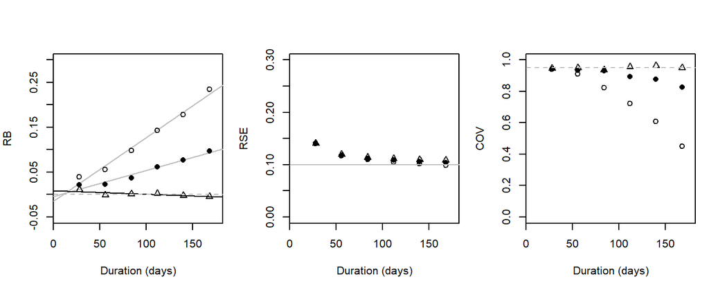

Relative bias RB, relative standard error RSE, and coverage of 95% confidence intervals COV for density estimates from studies of varying duration. Annual survival 50% (open circles), 75% (filled circles) or 100% (triangles). Horizontal lines for reference only.

## Interpretation

Increasing sample size resulted in a small reduction in the estimated sampling variance, but improvement was negligible after 12 weeks. Conversely, the coverage of confidence intervals was OK for durations up to 12 weeks ($\phi = 0.75$) or 8 weeks ($\phi = 0.5$), but poor thereafter.

[output not shown]

Results are specific to a population with no upward or downward trend.

## One-off

Run this code to obtain results for a single scenario. Requires secrdesign $\ge$ 2.9.0.

```r
source('../setup.R')
nsess  <- 12  # weeks
phi    <- 0.5  # annual survival
phiw   <- exp(log(phi)/52)   # convert annual to weekly survival
grid   <- make.grid(nx = 8, ny = 8, spacing = 3000, detector = "proximity")
poparg <- list(core = grid, buffer = 10000, D = 0.001, nsessions = nsess,
               details = list(lambda = 1, phi = phiw))
detarg <- list(traps = grid, detectfn = 'HHN', detectpar = list(lambda0 = 0.2, sigma = 2000),
               renumber = FALSE, noccasions = 1)
fitarg <- list(mask = make.mask(grid, buffer = 10000, type = 'trapbuffer'), detectfn = 'HHN')
scen   <- make.scenarios( D = 0.001, noccasions = 1, detectfn = 'HHN', lambda0 = 0.2, sigma = 2000)
sims1  <- run.scenarios(nrepl = 100, scen, trapset = list(grid), pop.args = poparg, det.args = detarg,
                      joinsessions = TRUE, fit = TRUE, fit.args = fitarg, seed = 12345)
summary(sims1)
```